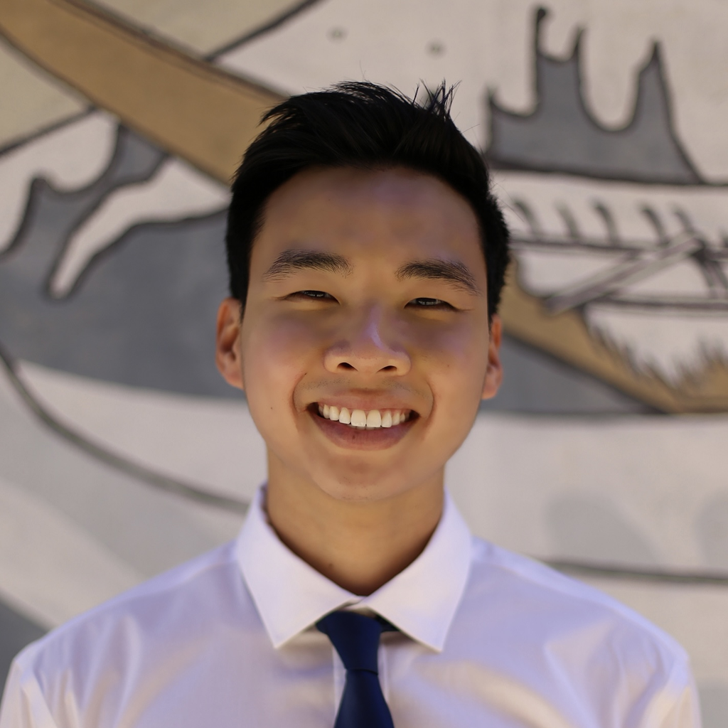

# Tony Le

## Hello world! 👋

I am a biomechanical engineer focused on using biomechanics, robotics, and data science to drive innovation in medical devices and health technologies.

I earned my PhD in Biomedical Engineering at the University of Utah in 2025, where I conducted research in the [FAMM Lab](https://lenzfammlab.mech.utah.edu/) within the Department of Mechanical Engineering. My work focused on foot and ankle orthopaedic biomechanics, developing a robotic cadaveric simulator with an integrated tendon force actuator system to study the kinematic mechanisms of the talocrural, subtalar, and midtarsal joints. This research combines biomechanics, robotics, and machine learning to provide a unique interdisciplinary approach to understanding foot and ankle function.

I also completed Graduate Certificate in Deep Learning in AI & Robotics from the Kahlert School of Computing at the University of Utah, where I strengthened my expertise in robotics and machine learning through advanced coursework in machine learning, deep learning, data visualization, and medical robotics.

## Career Objective 🚀

My career goal is to leverage robotics and data science to address real-world problems and create positive impact, particularly for disadvantaged and underrepresented communities.

I am seeking opportunities as a research engineer, product development engineer, clinical development engineer, or systems engineer in medical robotics, medical devices, or health technology.

#### Programming Languages 👨🏻‍💻️

**Proficient:** Python, MATLAB, R, LabView  
**Familiar:** SQL, Julia, C/C++, HTML/CSS, JavaScript

#### Tools & Software 🛠️

**Data Analysis & Visualization:** Pandas, NumPy, Matplotlib, Seaborn, Plotly, ggplot2, Tableau, Power BI  
**Machine Learning Frameworks:** PyTorch, TensorFlow/Keras, scikit-learn, statsmodels  
**Statistical Techniques:** Descriptive Statistics, Hypothesis Testing, Regression Analysis, Time-Series Analysis, Bayesian Inference, Statistical Parametric Mapping, Resampling Methods, Design of Experiments, Correlation  
**Development Tools:** VS Code, Jupyter Notebook, Anaconda, RStudio, Git/GitHub, Linux, OOP  
**Robotics:** ROS/ROS2, Gazebo, RViz, MoveIt2, RoboDK  
**3D Motion Capture:** OptiTrack, Optotrak Certus, Vicon  
**Musculoskeletal Modeling:** OpenSim  
**Finite Element Analysis:** FeBio  
**CAD Tools:** SolidWorks, Fusion 360  
**Functional Expertise:** Experimental Design, Scientific Communication, Technical Writing, Cross-Functional Collaboration, Project Management, Research & Development

## Background

I grew up in Spartanburg, SC and earned my BS in Chemistry with a minor in Applied Mathematics from Wofford College in 2015. After graduation, I interned as a research chemist at the E. & J. Gallo Winery Research Laboratory in Modesto, CA. My growing interests in medicine and engineering led me to Corvallis, OR, where I completed my MS in Bioengineering with a minor in Robotics at Oregon State University. Under the guidance of [Ravi Balasubramanian](https://engineering.oregonstate.edu/people/ravi-balasubramanian) and Jim Sweeney, I developed data-driven biomechanical models for simulating the kinematics and dynamics of novel implantable passive mechanisms for upper extremity tendon transfer surgery.

When I am not designing hardware or troubleshooting code, I am out mountain biking, rock climbing, skiing, or hiking with my dog and friends.

## Education 🎓

**PhD in Biomedical Engineering** | University of Utah | Aug 2025

**Graduate Certificate in Deep Learning in AI & Robotics** | University of Utah | May 2025

**MS in Bioengineering, Minor in Robotics** | Oregon State University | Dec 2020

**BS in Chemistry, Minor in Mathematics** | Wofford College | May 2015

## Experiences 👨🏻‍🔬

**Graduate Research Assistant** | Utah Orthopaedic Research Laboratory | Jan 2022–Present

**Research Analyst** | Utah Orthopaedic Research Laboratory | Oct–Dec 2021

**Musculoskeletal Biomechanics Research Fellow** | Walter Reed National Military Medical Center | Mar 2020–Sept 2021

**Graduate Research Assistant** | Robotic & Human Control Systems Laboratory | Sept 2016–Feb 2020

**Chemistry Research Intern** | E. & J. Gallo Winery Research Laboratory | Jun–Nov 2015

## Honors & Awards 🏅

**David Winter Young Investigator Award Finalist** | International Society of Biomechanics | May 2023

**Best Doctoral Poster Presentation Award** | Rocky Mountain American Society of Biomechanics | Apr 2023

**Arthroscopy Journal Award for Basic Science Research Excellence Runner-Up** | Arthroscopy: The Journal of Arthroscopic and Related Surgery | Jan 2022

**Dean’s Distinguished Graduate Fellowship (Declined)** | University of California, Davis | Apr 2021

**Musculoskeletal Biomechanics Research Fellowship** | Oak Ridge Institute for Science and Education | Jan 2020

**Science Communication Fellowship (Declined)** | Oregon Museum of Science and Industry | Nov 2018

**Blue Ribbon Poster Award** | Orthopaedic Research Society | Aug 2017

## Leadership & Service 🤓

**American Society of Biomechanics - Utah Student Chapter** | Vice President/Treasurer | Aug 2022–May 2025

**Utah BME Graduate Student Advisory Committee** | EDI Co-Chair, Co-Treasurer | Aug 2021–May 2025

**Utah Graduate Women in Biomedical Engineering** | Member | Jan 2022–May 2025

**OSU CBEE Graduate Student Association** | Bioengineering Chairman | 2017–2018

**OSU Robotics Graduate Student Association** | Co-Founder & Co-President | 2016–2018

## Community 🌱

**TEDx Salt Lake City** | Organizing Committee | 2023–Present

**Wasatch Adaptive Sports** | Snowbird, UT | 2021–Present

**WeDo Lego Robotics** | OSU STEM Academy | 2016–2019

**Makers Club** | Corvallis-Benton County Public Library | 2016

## News & Press 📰

[**OSU College of Engineering**](https://cbee.oregonstate.edu/node/809) | Sept 2019

[**Momentum Magazine**](http://www.journalgraphicsdigitalpublications.com/epubs/OSUALUMNIASSOCIATIONINC/MomentumSpring2019/viewer/desktop/) | Jun 2019